# Análisis de ocurrencias GBIF - Género Amanita en Colombia (Taller 1)

Mariana Areiza Sánchez

2026-02-10

En Colombia, especialmente en zonas altoandinas cercanas a Medellín, el género Amanita es ecológicamente relevante por su papel como hongo ectomicorrízico, formando asociaciones simbióticas con árboles como el roble andino (*Quercus humboldtii*) y con especies introducidas de pino. A través de estas interacciones participa activamente en el intercambio de nutrientes, la dinámica del suelo y el funcionamiento de los ecosistemas forestales andinos. Además, el género tiene importancia científica debido a su diversidad, a la presencia de especies tanto nativas como introducidas y a su utilidad en estudios de biogeografía, ecología de micorrizas y cambios en comunidades fúngicas. También posee relevancia educativa y sanitaria, ya que incluye especies tóxicas y otras comestibles, lo que hace fundamental su correcta identificación.

Realicé la búsqueda por medio de “ocurrencias” en GBIF, seleccioné únicamente a Colombia y en Nombre científico, coloqué Amanita (Fungi → Basidiomycota → Agaricomycetes → Agaricales → Amanitaceae) y seleccioné una zona bien definida de Colombia por medio de coordenadas, cerca a Medellín, obteniendo así 990 observaciones, las cuales fueron descargadas en archivo simple .CSV.

# 1.Descargue de GBIF un grupo de organismos de interes (entre 100-1000 registros)

## Primero realicé la descarga de los datos de ocurrencia en parte de Colombia (Principalmente cerca a Medellín), de Amanita como género, obteniendo 990 observaciones.

# 2. Genere una gráfica con la ocurrencia de este grupo (por ejemplo un barplot) y registre los comandos utilizados.

## 2.1 Procedí con la creación de las tablas en R, para organizar la información obtenida de los datos de ocurrencia de Amanita.

```r
# definimos como directorio de trabajo la carpeta creada
setwd("C:/Users/marya/Bio_Computacional/Proyecto_A.muscaria")

# leemos los datos descargados y guardados
gbif_data <- read.csv(
  "Datos_A.muscaria.csv",
  row.names = NULL, #necesario para que no numere las filas
  stringsAsFactors = FALSE,
  sep = "\t" #la separación de columnas es tipo "tab"
)

#gbif_data <- read_csv("Datos_A.muscaria.csv")

#Cuantas especies hay?
tabla_sp <- table(gbif_data$species)
```

## 2.2 Luego de tener la tabla con los datos bien organizados, procedí con los gráficos que muestra Cuántas especies de este género (Amanita) se reportan en la base de datos específicamente en Colombia.

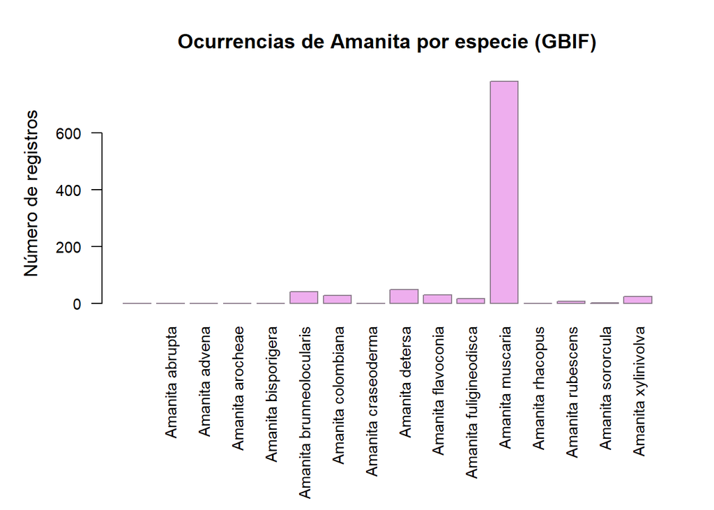

```r
# Ajustar márgenes
par(mar = c(10, 5, 4, 2))

barplot(
tabla_sp,
las = 2, # etiquetas verticales
col = "#EEAEEE",
border = "#8B7B8B",
main = "Ocurrencias de Amanita por especie (GBIF)",
ylab = "Número de registros",
cex.names = 0.9, # tamaño de nombres en eje X
cex.axis = 0.9, # tamaño de números
cex.lab = 1.1, # tamaño etiquetas de ejes
cex.main = 1.2 # tamaño del título
)
```

La gráfica muestra el número de registros en GBIF para distintas especies del género Amanita y evidencia una clara dominancia *Amanita muscaria*, que concentra con gran diferencia la mayor cantidad de ocurrencias (muy por encima de 600), mientras que el resto de especies presentan valores considerablemente menores, en su mayoría por debajo de 60 registros. Esto sugiere un sesgo de muestreo y/o mayor facilidad de identificación de *A. muscaria*, probablemente debido a su morfología conspicua y amplia distribución, mientras que las demás especies podrían estar subregistradas o tener distribuciones más restringidas. En términos de datos de biodiversidad, la gráfica refleja más la intensidad de registro y documentación que necesariamente la abundancia real en campo.

# 3. Usando comandos de linux, cree un directorio llamado “taller1”, y dentro de este, los siguientes subdirectorios:

## Luego creé el directorio principal llamado “taller1” en Linux (WSL)

mkdir taller1

# 4. Subdirectorios “data” y “scripts”

cd taller1

mkdir data

mkdir scripts

ls

# 5. data/ donde guardarás el archivo descargado de GBIF

## Procedí a guardar el archivo descargado de GBIF “Datos_A.muscaria.csv” en el subdirectorio “data”

cd taller1

mv /home/marya/Biocomp_repo/Datos_A.muscaria.csv data/

ls

# 6. Cuente las filas del documento descargado desde Linux

## Utilizando la función wc -l, conté las líneas del archivo “Datos_A.muscaria.csv”, dando como resultado que el archivo contiene 991 líneas; una corresponde al encabezado, por lo que hay 990 registros efectivos.

cd data

wc -l Datos_A.muscaria.csv

991 Datos_A.muscaria.csv

# 7. Finalmente, guardé el RMarkdown en el subdirectorio “scripts”

cd taller1

mv /home/marya/Biocomp_repo/Proyecto_Amanita_muscaria.Rmd scripts/

ls